# Next Word Predictor Application

Varun Poddar  
March 22, 2018

Overview:  
As part of the Coursera Data Science Capstone, this application seeks to build a predictive text application using natural language processing (NLP) techniques. This application is built using three English language datasets.

### Approach

The following steps were followed to construct a predictive model:

- Load data from text files
- Clean data
- Generate corpus
- Clean / transform the corpus
- Generate n-grams (1, 2, 3, and 4-grams) & write to output files
- Aggregate n-gram files to get frequencies by n-gram
- Break n-grams into “base” and “prediction”
- Test prediction algorithms
- Build into Shiny Application

### Exploratory Research

With quanteda, network graphs were used to show relationships between words (unigrams / bigrams) that occur together most frequently.

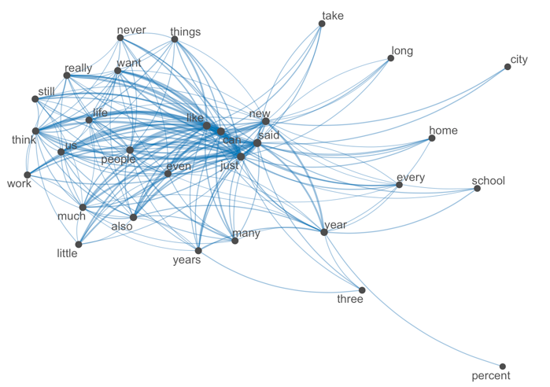

Frequencies of higher degree n-grams that are unlikely to occur simultaneously were observed with word clouds.

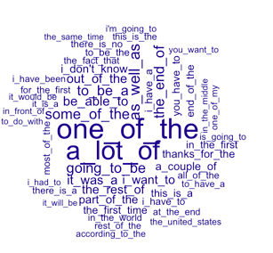

### Algorithm

- The prediction algorithm used is Katz's backoff model, which helped estimate the conditional probability of a word given its history in the n-gram.
- First the last three letters of the user-entered phrase are compared with the 4-gram data. If a match is found, the predicted word is returned.
- Then, if this fails to return a match, just the last two words are compared with the 3-gram data. If a match is found, then the predicted word is returned.
- Lastly, if this also fails to result in a match, just the last word is compared with the 2-gram data, to return the predicted word.
- If no matching data is found, then “the” is returned as default.

### Using The Application

The application hosted on Shiny's servers provides users with a simple textbox to enter their phrase. Once the user clicks “Update” the algorithm recommends the predicted word. The “About” tab contains additional documentation in case need be.

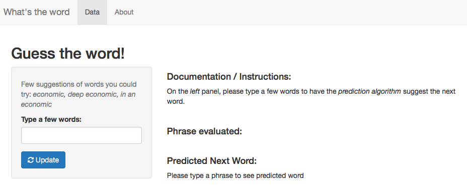

Link to Application: https://varunpoddar.shinyapps.io/nextWord/